# MauricioDeGarayHernandez_Dimensionality Reduction

#### Checking correlation

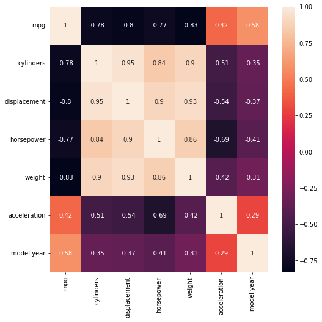

```python
plt.figure(figsize=(8,8))
sns.heatmap(data.corr(), annot=True)
plt.show()
```

**Observations:**

- The variable mpg has strong negative correlation with cylinders, displacement, horsepower, and weight.
- horsepower and acceleration are negatively correlated.
- The variable weight has strong positively correlation with horsepower, displacement and cylinders
- model year is positively correlated with mpg.

#### Scaling the data

```python
# scaling the data
scaler=StandardScaler()
data_scaled=pd.DataFrame(scaler.fit_transform(data), columns=data.columns)
```

```python
data_scaled.head()
```

|  | mpg | cylinders | displacement | horsepower | weight | acceleration | model year |
| --- | --- | --- | --- | --- | --- | --- | --- |
| 0 | -0.706439 | 1.498191 | 1.090604 | 0.673118 | 0.630870 | -1.295498 | -1.627426 |
| 1 | -1.090751 | 1.498191 | 1.503514 | 1.589958 | 0.854333 | -1.477038 | -1.627426 |
| 2 | -0.706439 | 1.498191 | 1.196232 | 1.197027 | 0.550470 | -1.658577 | -1.627426 |
| 3 | -0.962647 | 1.498191 | 1.061796 | 1.197027 | 0.546923 | -1.295498 | -1.627426 |
| 4 | -0.834543 | 1.498191 | 1.042591 | 0.935072 | 0.565841 | -1.840117 | -1.627426 |

## Principal Component Analysis

#### Question 3:

- **Apply the PCA algorithm with number of components equal to the total number of columns in the data with random_state=1 (2 Marks)**
- **Write observations on the variance explained by components (2 Marks)**

```python
#Defining the number of principal components to generate
n=data_scaled.shape[1]

#Finding principal components for the data
pca = PCA(n_components=n, random_state=1)#Apply the PCA algorithm with random state = 1
data_pca1 = pd.DataFrame(pca.fit_transform(data_scaled)) #Fit and transform the pca function on scaled data

#The percentage of variance explained by each principal component
exp_var = pca.explained_variance_ratio_
```

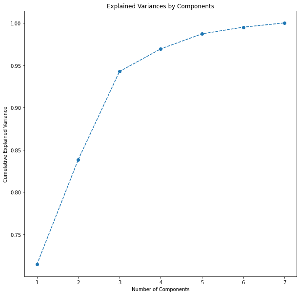

```python
# visualize the explained variance by individual components
plt.figure(figsize = (10,10))
plt.plot(range(1,8), exp_var.cumsum(), marker = 'o', linestyle = '--')
plt.title("Explained Variances by Components")
plt.xlabel("Number of Components")
plt.ylabel("Cumulative Explained Variance")
```

```python
# find the least number of components that can explain more than 90% variance
sum = 0
for ix, i in enumerate(exp_var):
  sum = sum + i
  if(sum>0.90):
    print("Number of PCs that explain at least 90% variance: ", ix+1)
    break
```

```
Number of PCs that explain at least 90% variance:  3
```

**Observations:**

- If we apply PCA with number of components=number of columns and random state=1, we can explain 90% of the variance with 3 Principal Components.
- As we know, if we maximize this variance, we can explain the data set with less dimensions while losing the least amount of information.
- Because of this 90% variance is very good, specially since we will only need 3 PCs.
- 2 PCs only explain less than 85%, while 1 explains less than 75% variance. 4 principal components manages to explain over 95%, so that is also a good amount of variance explained.
- However, 3 PCs seems to be a good sweet spot between variance explained and simplicity.

```python
pc_comps = ['PC1','PC2','PC3']
data_pca = pd.DataFrame(np.round(pca.components_[:3,:],2),index=pc_comps,columns=data_scaled.columns)
data_pca.T
```

|  | PC1 | PC2 | PC3 |
| --- | --- | --- | --- |
| mpg | -0.40 | -0.21 | -0.26 |
| cylinders | 0.42 | -0.19 | 0.14 |
| displacement | 0.43 | -0.18 | 0.10 |
| horsepower | 0.42 | -0.09 | -0.17 |
| weight | 0.41 | -0.22 | 0.28 |
| acceleration | -0.28 | 0.02 | 0.89 |
| model year | -0.23 | -0.91 | -0.02 |